# Lab 045 — TabTransformer: contextual categorical embeddings + self-supervised pre-training

## Follow the computation

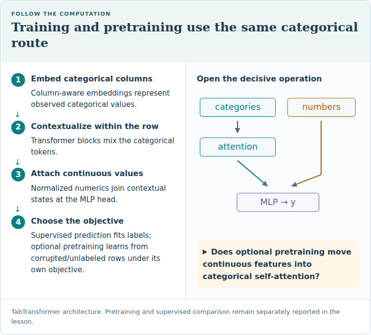

TabTransformer architecture. Pretraining and supervised comparison remain separately reported in the lesson.

**Trace question:** Does optional pretraining move continuous features into categorical self-attention?

**Trace answer:** No. A different training objective does not by itself change the input topology.

**Lesson:** `lessons/0045-tabtransformer.html` · **Phase / Year:** Year 2 · Q1

**Paper:** Huang, Khetan, Cvitkovic & Karnin 2020, *TabTransformer: Tabular Data Modeling Using Contextual Embeddings* ([arXiv:2012.06678](https://arxiv.org/abs/2012.06678)) — Fig. 1 (architecture), §3.1–3.2 (column embedding + Transformer), §3.3 (RTD pre-training). Self-attention: Vaswani et al. 2017 ([arXiv:1706.03762](https://arxiv.org/abs/1706.03762)). Static entity embeddings: L031/L032.

**Dataset tier:** **A** — small real OpenML tables via `relkit` (CPU-cheap; deliberately NOT representative — see the #23 notes in Tasks 3–4).

**Skill you are practising:** promote the forward-only model you built in L032 to a *trained*, *pre-trainable* one — (1) the **RTD corruption**, (2) the **self-supervised pre-training step**, then (3) race **contextual vs context-free (n_layers=0) vs CatBoost**, and (4) measure the **label-efficiency** payoff of pre-training. Name the limitation: numeric features bypass the attention.

**Exit criteria:** EXIT TICKET prints your RTD validation, the pretext-step detector AUC, the contextual-vs-context-free probe, the bake-off ranks, the label-efficiency lift, and one sentence — *what does context buy, and where does it stop?*

### How this notebook works

- **PROVIDED** cells — boilerplate (data, frame, budgets, CatBoost/pretrain harnesses) **and** the paper's encoder / train / RTD loops copied into the notebook (not hidden behind `import relkit.tabtransformer`); just run.
- **TODO** cells — blanks (`____`); you implement the skill.
- **CHECK** cells — immediate feedback; do not edit.
- Run top to bottom. After EXIT, a **NEXT STEP** cell trains closer to the paper (Colab GPU or Modal). When **EXIT TICKET** prints cleanly, paste it to your teacher or say *"lab done"*.

### Environment

One-time: `bash labs/setup-env.sh` → kernel **Relational Labs (.venv)**. Needs **torch** + scikit-learn + **catboost** (CPU is fine). Real datasets fetch from OpenML on first run then cache. Budget: **~8–12 minutes on CPU** — set `OMP_NUM_THREADS=1` if a search feels slow (that has been the real cause of every slow lab so far). This lab uses a deliberately small budget/seed/dataset count to stay interactive; the lesson's headline numbers come from the fuller `labs/_verify_l045.py` run plus the paper's 15-dataset benchmark.

### Running on Google Colab?

Colab opens only this single file, so the course package (`relkit`) and the lab dependencies (xgboost, lightgbm, catboost, …) are **not** present by default. The cell below fixes that: on Colab it shallow-clones the course repo, installs `requirements-labs.txt`, and switches into `labs/` so `relkit` imports and the data cache resolve. **On a local venv or your own Jupyter it does nothing — just run it and continue.**

```python
# @colab-bootstrap — PROVIDED. Makes the lab self-sufficient on Google Colab; a no-op elsewhere.
import os, sys

if "google.colab" in sys.modules:
    if not os.path.isdir("/content/relational"):
        !git clone --depth 1 https://github.com/Avistian/relational.git /content/relational
    %pip install -q -r /content/relational/requirements-labs.txt
    os.chdir("/content/relational/labs")
    print("Colab ready — working dir:", os.getcwd())
else:
    print("Not on Colab — using the local environment as-is.")
```

## Concept recap — what TabTransformer adds to the static embedding

**The architecture (Huang 2020, Fig. 1).**

1. **Column embedding** — each categorical column has its own embedding table (the L031 entity embedding).
2. **Transformer stack** — `n_layers` blocks of multi-head self-attention + FFN turn the static tokens into **contextual** ones. `n_layers = 0` is the *context-free ablation* — literally the L031/L032 model.
3. **Numerics bypass** — continuous features skip the Transformer, get a `LayerNorm`, and are **concatenated** to the flattened contextual tokens. **This is the known limitation:** numbers never attend to anything.
4. **MLP head** — the concatenated vector → MLP → one logit.

**Self-supervised pre-training (§3.3).** Because the pretext task — **Replaced Token Detection** — is built from the row itself, TabTransformer can learn from **unlabeled** rows: corrupt some categorical tokens, and train a per-column detector to flag them. Detecting a swap *requires* context (a swapped value only looks wrong next to its neighbours), so the pretext directly sharpens the contextual encoder. Then fine-tune on a few labels. Trees cannot do this.

Full write-up + the static-vs-contextual and RTD widgets: Lesson 045.

## Setup — PROVIDED (categorical-rich tables + shared frame + budgets)

```python
# PROVIDED — imports, the categorical-rich tables, the shared frame, and the budgets. Just run.
# The TabTransformer *architecture* is inlined in a later cell so you can read it (Huang 2020, Fig. 1 + §3).
# `relkit.tabtransformer` here is only a data helper + a Task-1 checker (NOTES #22 / #25).
# The attention itself you already built forward-only in Lab 032; it is re-validated in labs/_check_l045.py.
import warnings
warnings.filterwarnings("ignore")

import time
import numpy as np
import torch
from scipy.stats import rankdata, friedmanchisquare
from sklearn.model_selection import train_test_split
from sklearn.metrics import roc_auc_score

import sys
from pathlib import Path
sys.path.insert(0, str(Path(".").resolve()))          # labs/ when run from there
sys.path.insert(0, str(Path(".").resolve().parent))   # labs/ when run from labs/solutions/
from relkit import load_tier_a
from relkit.tabtransformer import (
    frame_categorical,                                         # data helper (not the model)
    corrupt_categorical as relkit_corrupt,                     # checker only (NOTES #22)
)

DEVICE = "cpu"
DATASETS  = ["credit_g", "adult"]     # categorical-rich; adult subsampled below (churn is numeric-heavy)
SUBSAMPLE = {"adult": 3000}           # keep CPU cost bounded — a down-scaled demonstration (#20/#23)
SEEDS = [0, 1]                        # smaller than the lesson's 3-seed/3-dataset run, to stay interactive
EPOCHS, PATIENCE, BS, LR = 50, 10, 256, 1e-3
TT_CFG = dict(d=32, n_layers=3, n_heads=4, head_hidden=128, dropout=0.1)   # CONTEXTUAL
CF_CFG = dict(d=32, n_layers=0,          head_hidden=128, dropout=0.1)     # CONTEXT-FREE (L031/L032)
# Task 4 needs a LARGE unlabeled pool so pre-training has something to learn and fine-tuning does not
# catastrophically forget (a small pool was what produced negative lifts — see the reproducibility ledger).
SEMI_N, SEMI_FRAC, PRE_EPOCHS, FT_LR = 14000, 0.03, 25, 5e-4

def load_frame(name, cap=None):
    """Encode a table into TabTransformer's inputs: integer-coded categoricals + standardised numerics.
    `cap` (or the SUBSAMPLE default) bounds the row count so the lab stays CPU-cheap."""
    Xdf, y = load_tier_a(name)
    cap = cap if cap is not None else SUBSAMPLE.get(name)
    if cap and len(Xdf) > cap:
        idx, _ = train_test_split(np.arange(len(Xdf)), train_size=cap, random_state=0, stratify=y)
        Xdf, y = Xdf.iloc[idx].reset_index(drop=True), y.iloc[idx].reset_index(drop=True)
    Xcat, Xnum, cards, cat_names, num_names = frame_categorical(Xdf)
    return {"Xdf": Xdf, "y": y.to_numpy().astype(np.float32), "Xcat": Xcat, "Xnum": Xnum,
            "cards": cards, "cat_names": cat_names, "num_names": num_names}

def split_idx(n, y, seed):
    """The SHARED frame — identical train/val/test for every arm (L020 contract, L042 protocol)."""
    tr, te = train_test_split(np.arange(n), test_size=0.30, random_state=seed, stratify=y)
    tr, va = train_test_split(tr, test_size=0.25, random_state=seed, stratify=y[tr])
    return tr, va, te

def run_tt(fr, tr, va, te, cfg, seed):
    """Train one TabTransformer arm (cfg picks CONTEXTUAL vs CONTEXT-FREE) and score it on test."""
    torch.manual_seed(seed)
    m = TabTransformer(fr["cards"], fr["Xnum"].shape[1], **cfg)
    m, val = train_tabtransformer(m, fr["Xcat"][tr], fr["Xnum"][tr], fr["y"][tr],
                                  fr["Xcat"][va], fr["Xnum"][va], fr["y"][va],
                                  lr=LR, max_epochs=EPOCHS, patience=PATIENCE, batch_size=BS, seed=seed)
    return val, tabtransformer_auc(m, fr["Xcat"][te], fr["Xnum"][te], fr["y"][te])

def run_catboost(fr, tr, va, te, seed):
    """CatBoost with NATIVE categorical handling (its strength on categorical-rich data) — the honest bar."""
    from catboost import CatBoostClassifier
    Xdf = fr["Xdf"]; cat_idx = [Xdf.columns.get_loc(c) for c in fr["cat_names"]]
    Xstr = Xdf.copy()
    for c in fr["cat_names"]:
        Xstr[c] = Xstr[c].map(str).astype(object)     # plain str (CatBoost rejects category-dtype NaN)
    clf = CatBoostClassifier(depth=6, iterations=300, learning_rate=0.05, l2_leaf_reg=3.0,
                             random_seed=seed, thread_count=2, verbose=0, allow_writing_files=False)
    clf.fit(Xstr.iloc[tr], fr["y"][tr].astype(int), cat_features=cat_idx,
            eval_set=(Xstr.iloc[va], fr["y"][va].astype(int)))
    return roc_auc_score(fr["y"][te], clf.predict_proba(Xstr.iloc[te])[:, 1])

print("setup ok — torch", torch.__version__)
```

## Task 1 — `corrupt_categorical`: the label-free pretext (Replaced Token Detection)

**Goal.** Write the corruption that powers self-supervised pre-training: independently, with probability `p`, replace each categorical token with **another category drawn uniformly** from that column's range, and return the 0/1 **label** the detector must recover — *which cells were tampered with?*

**Why it needs no labels.** The target is manufactured from the row itself, so *any* unlabeled row is training signal. Detecting a swap forces the encoder to learn what a **coherent row** looks like — which category values plausibly co-occur — the exact structure that then transfers to the real task ([Huang §3.3](https://arxiv.org/abs/2012.06678), ELECTRA-style).

**The one subtlety.** A uniform redraw can land on the *original* value. That cell is **not** replaced, so its label must be 0. Define the label by comparing the corrupted tokens to the originals, not by the coin flip. That is why the *effective* replaced fraction is `p·(1 − 1/card)`, strictly below `p`.

```python
# TODO — implement the RTD corruption. Fill every ____.
def corrupt_categorical(Xcat, cards, p, generator):
    """Xcat: LongTensor [N, m] integer-coded categoricals. cards[j] = # categories in column j.
    Returns (Xcorrupt [N, m] long, replaced [N, m] float 0/1)."""
    N, m = Xcat.shape
    # 1) coin flip per cell: replace with probability p
    replace_mask = torch.rand(N, m, generator=generator) < p
    # 2) a uniform random category per column (the candidate replacement)
    rand_vals = torch.zeros(N, m, dtype=torch.long)
    for j, c in enumerate(cards):
        rand_vals[:, j] = torch.randint(0, max(c, 1), (N,), generator=generator)
    # 3) where the coin said "replace", swap in the random category; else keep the original
    Xcorrupt = ____
    # 4) the LABEL is "did the value actually change?" — a redraw equal to the original counts as UNCHANGED
    replaced = ____
    return Xcorrupt, replaced

# quick look
g = torch.Generator().manual_seed(0)
demo = torch.tensor([[0, 1, 2], [2, 0, 1], [1, 2, 0]])
xc, rep = corrupt_categorical(demo, [3, 3, 3], 0.5, g)
print("original :\n", demo.numpy())
print("corrupted:\n", xc.numpy())
print("replaced :\n", rep.numpy(), "  (1 = detector must flag this cell)")
```

```python
# CHECK — the invariants that make RTD a valid label-free pretext (do not edit)
ok = True
def chk(name, cond, detail=""):
    global ok
    print(("PASS  " if cond else "FAIL  ") + name + (f"   [{detail}]" if detail else ""))
    if not cond: ok = False

rng = np.random.default_rng(0)
cards = [2, 5, 10, 3, 7]
X = torch.tensor(np.stack([rng.integers(0, c, size=4000) for c in cards], axis=1), dtype=torch.long)

# p = 0 changes nothing -> no signal without corruption
g0 = torch.Generator().manual_seed(1)
xc0, rep0 = corrupt_categorical(X, cards, 0.0, g0)
chk("p=0 corrupts nothing", bool((xc0 == X).all()) and float(rep0.sum()) == 0.0)

# a labelled cell truly changed; an unlabelled cell truly did not
g1 = torch.Generator().manual_seed(2)
xc, rep = corrupt_categorical(X, cards, 0.30, g1)
chk("every replaced=1 cell actually changed value", bool((xc[rep == 1] != X[rep == 1]).all()))
chk("every replaced=0 cell is unchanged", bool((xc[rep == 0] == X[rep == 0]).all()))

# effective replaced fraction = mean_j p*(1 - 1/card_j), STRICTLY below p (collisions relabelled)
eff = rep.mean().item()
expected = float(np.mean([0.30 * (1 - 1 / c) for c in cards]))
chk("effective replaced fraction matches p*(1-1/card), below p", abs(eff - expected) < 0.02 and eff < 0.30,
    f"eff {eff:.3f} vs expected {expected:.3f} (< p=0.30)")

# deterministic in (p, seed); higher p replaces at least as much
ga, gb = torch.Generator().manual_seed(7), torch.Generator().manual_seed(7)
chk("deterministic given the generator seed",
    bool((corrupt_categorical(X, cards, 0.3, ga)[0] == corrupt_categorical(X, cards, 0.3, gb)[0]).all()))
g2, g3 = torch.Generator().manual_seed(3), torch.Generator().manual_seed(3)
chk("higher p replaces more (in expectation)",
    corrupt_categorical(X, cards, 0.6, g2)[1].mean() > corrupt_categorical(X, cards, 0.2, g3)[1].mean())

# VALIDATION against the from-scratch reference (NOTES #22)
ga, gb = torch.Generator().manual_seed(11), torch.Generator().manual_seed(11)
mine = corrupt_categorical(X, cards, 0.3, ga)[0]
ref = relkit_corrupt(X, cards, 0.3, gb)[0]
chk("VALIDATED against relkit.tabtransformer.corrupt_categorical", bool((mine == ref).all()))
print("\nTask 1", "OK" if ok else "-- fix the FAILs above")
```